# Analysis of MG63.3 YBX1 GUC clones by proteomics

This document details the analysis of proteomics data acquired to compare MG63.3 clones created with the GUC guide targeting YBX1. The raw MS data were compiled to peptide identifications using SearchGUI and PeptideShaker as detailed elsewhere in this folder.

## Setting up the environment

These are packages you will need for this notebook. For exact versions used, please refer to the session info at the bottom of this notebook.

```r
library('tidyverse')
library('ggplot2')
library('RColorBrewer')
library('vroom')
library('DEqMS')
library('ggrepel')
```

I want to set a base directory that we can use as a link to the directory where we will do most of the work. I use two directories here because the Workspace is what is pushed to GitHub and contains scripts and plot files, but the Repository is where more of the big data is stored that does not get pushed.

```r
generalDatasets = 'C:/Users/chughes/Documents/bccrc/projectsRepository/generalDatasets'
baseWorkspace = 'C:/Users/chughes/Documents/bccrc/projectsWorkspace/sorensenLab/relatedToYbx1'
baseRepository = 'C:/Users/chughes/Documents/bccrc/projectsRepository/sorensenLab/relatedToYbx1'
#generalDatasets = 'C:/Users/chris/OneDrive/Documents/bccrc/projectsRepository/generalDatasets'
#baseWorkspace = 'C:/Users/chris/OneDrive/Documents/bccrc/projectsWorkspace/sorensenLab/relatedToYbx1'
#baseRepository = 'C:/Users/chris/OneDrive/Documents/bccrc/projectsRepository/sorensenLab/relatedToYbx1'
```

We need to call a source file that has some functions we will need. For simplicity and ease of tracking, I make a copy of this file in each directory that I will work in in order to be able to trace the exact one functions that are used, in case I change them and mistakenly don’t push it to GitHub.

```r
source(paste(baseWorkspace, '/proteomics20200705_mg633CrisprYbx1GucClones/userDefinedFunctions.R', sep = ''))
```

## Data processing

I want to process the data using DEqMS. I am following their guide as detailed [here](https://www.bioconductor.org/packages/release/bioc/vignettes/DEqMS/inst/doc/DEqMS-package-vignette.html#quick-start). For this, I think we should add the gene annotation. We have the annotated fasta index, so we can use that.

```r
##########################################################################################
proteinAnnotation = readRDS(paste(baseRepository, '/proteomics20200705_mg633CrisprYbx1GucClones/uniprotHumanJul2020.fasta.annotated.rds', sep = ''))
```

Now I will read in the peptide search results.

```r
##########################################################################################
psm = vroom(paste(baseRepository, '/proteomics20200705_mg633CrisprYbx1GucClones/n_ch_20200704_Mg633-Ybx1GucKo_TMT9_HpH_1_Default_PSM_Report.txt', sep = '')) %>%
  dplyr::select(`Protein(s)`, Sequence, `Modified Sequence`, `Spectrum File`, `Spectrum Scan Number`) %>%
  mutate(fraction = sub('.*HpH_(.*)\\.raw\\.mgf$', '\\1', `Spectrum File`)) %>%
  mutate(accession = `Protein(s)`) %>%
  mutate(scan = `Spectrum Scan Number`) %>%
  mutate(sequence = Sequence) %>%
  mutate(modSequence = `Modified Sequence`) %>%
  left_join(proteinAnnotation) %>%
  dplyr::select(fraction, scan, accession, gene, detectablePeptides, sequence, modSequence)
```

```
* `` -> ...1
Rows: 125,406
Columns: 24
chr [16]: Protein(s), Sequence, AAs Before, AAs After, Position, Modified Sequence, Variable Modifications, Fixed Modifications, Spectrum File, Spectrum Title, Measured Charge, Id...
dbl [ 8]: ...1, Spectrum Scan Number, RT, m/z, Theoretical Mass, Isotope Number, Precursor m/z Error [ppm], Confidence [%]

Pass a specification to the `col_types` argument to quiet this message
```

Now we need the quantification data. These are hosted in individual files in the same directory as the above data.

```r
##########################################################################################
quantFiles = as.list(list.files(paste(baseRepository, '/proteomics20200705_mg633CrisprYbx1GucClones/quantFiles/', sep = ''),
           pattern = '_Matrix.txt', full.names = TRUE))
##
quantDataSet = lapply(quantFiles, combineQuantFiles)
```

```
[1] "Processing file for fraction 1."
[1] "Processing file for fraction 10."
[1] "Processing file for fraction 11."
[1] "Processing file for fraction 12."
[1] "Processing file for fraction 13."
[1] "Processing file for fraction 14."
[1] "Processing file for fraction 15."
[1] "Processing file for fraction 16."
[1] "Processing file for fraction 17."
[1] "Processing file for fraction 18."
[1] "Processing file for fraction 19."
[1] "Processing file for fraction 2."
[1] "Processing file for fraction 20."
[1] "Processing file for fraction 21."
[1] "Processing file for fraction 22."
```

[output cut: 21 more lines]

Now combine the quant data into a single data frame and with the previously processed PSM data.

```r
##########################################################################################
allQuantData = do.call('rbind', quantDataSet)
psmQuant = psm %>%
  left_join(allQuantData)
```

Now we will filter the expression data to discard any entries where the signal is just too low to be confident in the data. I generally will use a cutoff of a minimum signal of 10 per TMT channel. In this case we have 9 channels, so we will use a sum signal of 90 as a cutoff. Here we also filter out genes that have no assigned gene name as this will cause problems with DEqMS later on. If you don’t want to do this, I suggest using ‘accession’ instead of ‘gene’ in the DEqMS analysis below.

Our sample layout is:

- 126 - Guc4.1
- 127N - Guc6.1
- 127C - Guc4.2
- 128N - Guc6.2
- 128C - Guc4.3
- 129N - Guc6.3
- 129C - empty
- 130N - empty
- 130C - Parent.1
- 131N - Parent.2
- 131C - Parent.3

```r
##########################################################################################
psmQuant$sampleSignal = rowSums(psmQuant[,c(8:13,16:18)])
psmQuantFiltered = subset(psmQuant, psmQuant$sampleSignal >= 90 & !is.na(psmQuant$gene) & !grepl('-', psmQuant$gene))
```

We will also normalize the data to deal with any gross loading differences. We save both the non-normalized data here as well and check the normalization with a plot.

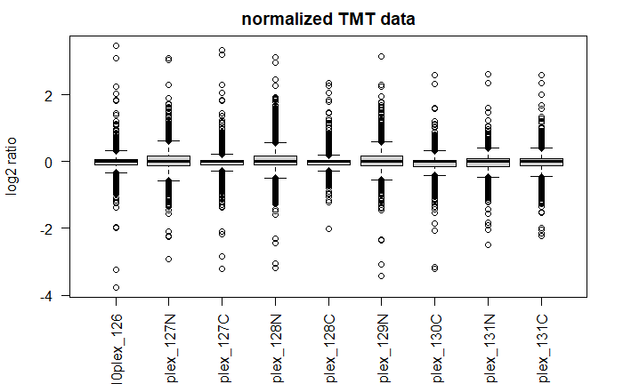

```r
##########################################################################################
quantInput = psmQuantFiltered[,c(1:18)]
saveRDS(quantInput, paste(baseRepository, '/proteomics20200705_mg633CrisprYbx1GucClones/dataset_peptideQuantDataPreDEqMS.rds', sep = ''))
quantInputLog = quantInput[,c(7,4,8:13,16:18)]
quantInputLog[,3:11][quantInputLog[,3:11] == 0] = NA
quantInputLog[,3:11] = log2(quantInputLog[,3:11])
quantInputNormalized = medianSweeping(quantInputLog, group_col = 2)
boxplot(quantInputNormalized, las = 2, ylab = 'log2 ratio', main = 'normalized TMT data')
```

All of the data look tight. Good. Lets continue with the DEqMS analysis. We need to build our sample table.

```r
##########################################################################################
cond = as.factor(c('guc4','guc6','guc4','guc6','guc4','guc6','parent','parent','parent'))
design = model.matrix(~0+cond)
colnames(design) = gsub("cond","",colnames(design))
```

Now we can build the Limma model.

```r
##########################################################################################
geneMatrix = as.matrix(quantInputNormalized)
limmaFit1 = lmFit(geneMatrix, design)
limmaContrasts = c('guc4-parent','guc6-parent','guc4-guc6')
limmaContrastDesign =  makeContrasts(contrasts = limmaContrasts, levels = design)
limmaFit2 = eBayes(contrasts.fit(limmaFit1, contrasts = limmaContrastDesign))
```

```r
##########################################################################################
psmCountTable = as.data.frame(table(quantInput$gene))
rownames(psmCountTable) = psmCountTable$Var1
limmaFit2$count = psmCountTable[rownames(limmaFit2$coefficients),2]
limmaFit3 = spectraCounteBayes(limmaFit2)
head(limmaFit3$coefficients)
```

```
       Contrasts
        guc4-parent guc6-parent   guc4-guc6
  A2M     0.1027367  0.49739850 -0.39466180
  AAAS    0.1077969  0.19710675 -0.08930985
  AACS   -0.1740756 -0.10184227 -0.07223335
  AAGAB   0.1015072 -0.21962878  0.32113601
  AAK1   -0.1814544  0.09941062 -0.28086497
  AAMDC   0.2477638  0.36660849 -0.11884473
```

```r
##
deqmsResults = outputResult(limmaFit3, coef_col = 1)
write.table(deqmsResults,
            paste(baseRepository, '/proteomics20200705_mg633CrisprYbx1GucClones/dataset_deqmsGuc4-Parent.csv', sep = ''),
            sep = ',', row.names = FALSE, quote = FALSE)
##
deqmsResults = outputResult(limmaFit3, coef_col = 2)
write.table(deqmsResults,
            paste(baseRepository, '/proteomics20200705_mg633CrisprYbx1GucClones/dataset_deqmsGuc6-Parent.csv', sep = ''),
            sep = ',', row.names = FALSE, quote = FALSE)
##
deqmsResults = outputResult(limmaFit3, coef_col = 3)
write.table(deqmsResults,
            paste(baseRepository, '/proteomics20200705_mg633CrisprYbx1GucClones/dataset_deqmsGuc4-Guc6.csv', sep = ''),
            sep = ',', row.names = FALSE, quote = FALSE)
```

Generate the variance plot to see the DEqMS model for the data.

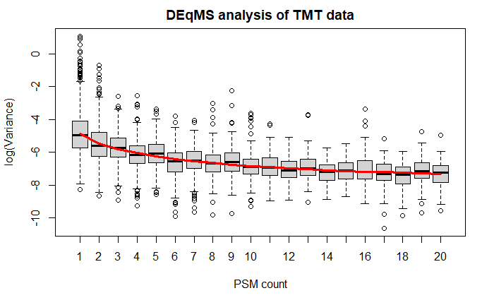

```r
##########################################################################################
VarianceBoxplot(limmaFit3, n=20, xlab = 'PSM count', main = 'DEqMS analysis of TMT data')
```

This looks as it should. Now let us make a volcano plot to show the data.

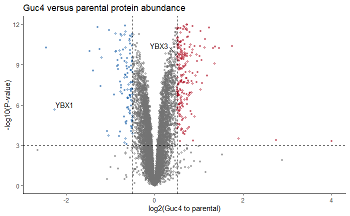

```r
##########################################################################################
deqmsResults = outputResult(limmaFit3, coef_col = 1)
deqmsResults$plotPValue = -log10(deqmsResults$sca.P.Value)
deqmsResults$pColors = ifelse(deqmsResults$logFC <= -0.5 & deqmsResults$plotPValue >= 3, brewer.pal(8,'RdBu')[8],
                              ifelse(deqmsResults$logFC >= 0.5 & deqmsResults$plotPValue >= 3, brewer.pal(8,'RdBu')[1],
                                     brewer.pal(8,'Greys')[6]))
deqmsResults$pText = ifelse(grepl('YBX[13]',deqmsResults$gene), deqmsResults$gene, '')
##
ggplot(deqmsResults, aes(logFC, plotPValue)) +
  geom_point(size = 1, color = deqmsResults$pColors, alpha = 0.5) +
  geom_text_repel(label = deqmsResults$pText) +
  labs(x = 'log2(Guc4 to parental)', y = '-log10(P-value)', title = 'Guc4 versus parental protein abundance') +
  scale_y_continuous(limits = c(0,12), breaks = seq(0,18,3)) +
  geom_vline(xintercept = c(-0.5,0.5), linetype = 'dashed') +
  geom_hline(yintercept = 3, linetype = 'dashed') +
  theme_classic()
ggsave(paste(baseRepository, '/proteomics20200705_mg633CrisprYbx1GucClones/scatter_deqmsGuc4-Parental.pdf', sep = ''),
       height = 4, width = 4, useDingbats = FALSE)
```

And the volcano for the other clone.

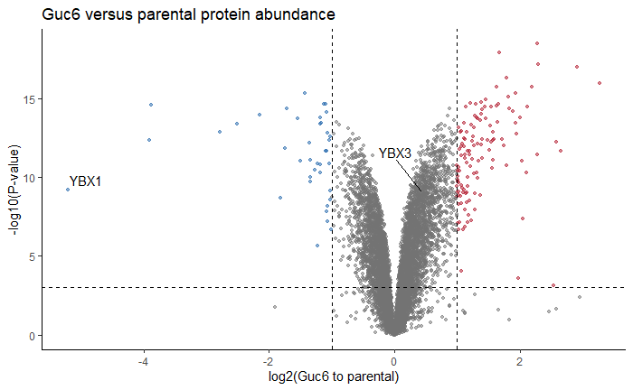

```r
##########################################################################################
deqmsResults = outputResult(limmaFit3, coef_col = 2)
deqmsResults$plotPValue = -log10(deqmsResults$sca.P.Value)
deqmsResults$pColors = ifelse(deqmsResults$logFC <= -1 & deqmsResults$plotPValue >= 3, brewer.pal(8,'RdBu')[8],
                              ifelse(deqmsResults$logFC >= 1 & deqmsResults$plotPValue >= 3, brewer.pal(8,'RdBu')[1],
                                     brewer.pal(8,'Greys')[6]))
deqmsResults$pText = ifelse(grepl('YBX[13]',deqmsResults$gene), deqmsResults$gene, '')
##
ggplot(deqmsResults, aes(logFC, plotPValue)) +
  geom_point(size = 1, color = deqmsResults$pColors, alpha = 0.5) +
  geom_text_repel(label = deqmsResults$pText) +
  labs(x = 'log2(Guc6 to parental)', y = '-log10(P-value)', title = 'Guc6 versus parental protein abundance') +
  #scale_y_continuous(limits = c(0,12), breaks = seq(0,18,3)) +
  geom_vline(xintercept = c(-1,1), linetype = 'dashed') +
  geom_hline(yintercept = 3, linetype = 'dashed') +
  theme_classic()
ggsave(paste(baseRepository, '/proteomics20200705_mg633CrisprYbx1GucClones/scatter_deqmsGuc6-Parental.pdf', sep = ''),
       height = 4, width = 4, useDingbats = FALSE)
```

Now overlay the two clones to look at shared changes.

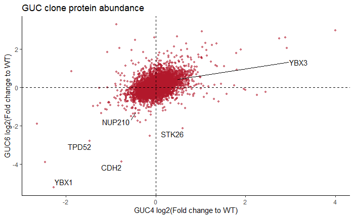

```r
##########################################################################################
guc4Results = outputResult(limmaFit3, coef_col = 1)
colnames(guc4Results)[1] = 'guc4Exp'
guc6Results = outputResult(limmaFit3, coef_col = 2)
colnames(guc6Results)[1] = 'guc6Exp'
gucSet = as_tibble(guc4Results) %>%
  dplyr::select(gene, guc4Exp) %>%
  left_join(guc6Results) %>%
  dplyr::select(gene, guc4Exp, guc6Exp)
goi = c('YBX1','YBX3','CDH2','TPD52','STK26','NUP210')
gucSet$pText = ifelse(gucSet$gene %in% goi, gucSet$gene, '')
##
ggplot(gucSet, aes(guc4Exp, guc6Exp)) +
  geom_point(size = 1, color = brewer.pal(8,'RdBu')[1], alpha = 0.5) +
  geom_text_repel(label = gucSet$pText) +
  labs(x = 'GUC4 log2(Fold change to WT)', y = 'GUC6 log2(Fold change to WT)', title = 'GUC clone protein abundance') +
  #scale_x_continuous(limits = c(-3.5,0), breaks = seq(-10,10,2)) +
  #scale_y_continuous(limits = c(-5.5,0), breaks = seq(-10,10,2)) +
  geom_vline(xintercept = 0, linetype = 'dashed') +
  geom_hline(yintercept = 0, linetype = 'dashed') +
  theme_classic()
ggsave(paste(baseRepository, '/proteomics20200705_mg633CrisprYbx1GucClones/scatter_deqmsGuc4-Guc6.pdf', sep = ''),
       height = 4, width = 4, useDingbats = FALSE)
```

```r
##
cor(gucSet$guc4Exp, gucSet$guc6Exp, use='pairwise.complete.obs', method = 'pearson')
```

```
[1] 0.4581747
```

[session information not shown]